# Baltimore Community Data Science Collaboration, ToolBank Community and Economic Impact Survey Analysis

**Figures 24a-b: Money saved through TB (avg year) by Toolbank service**

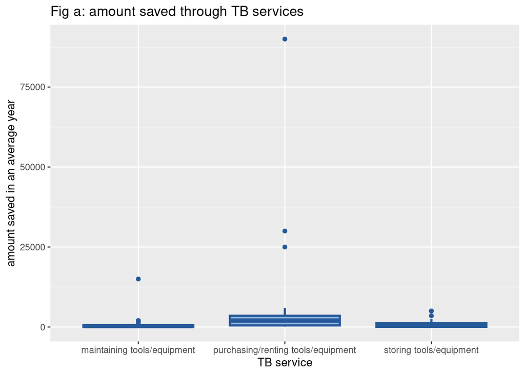

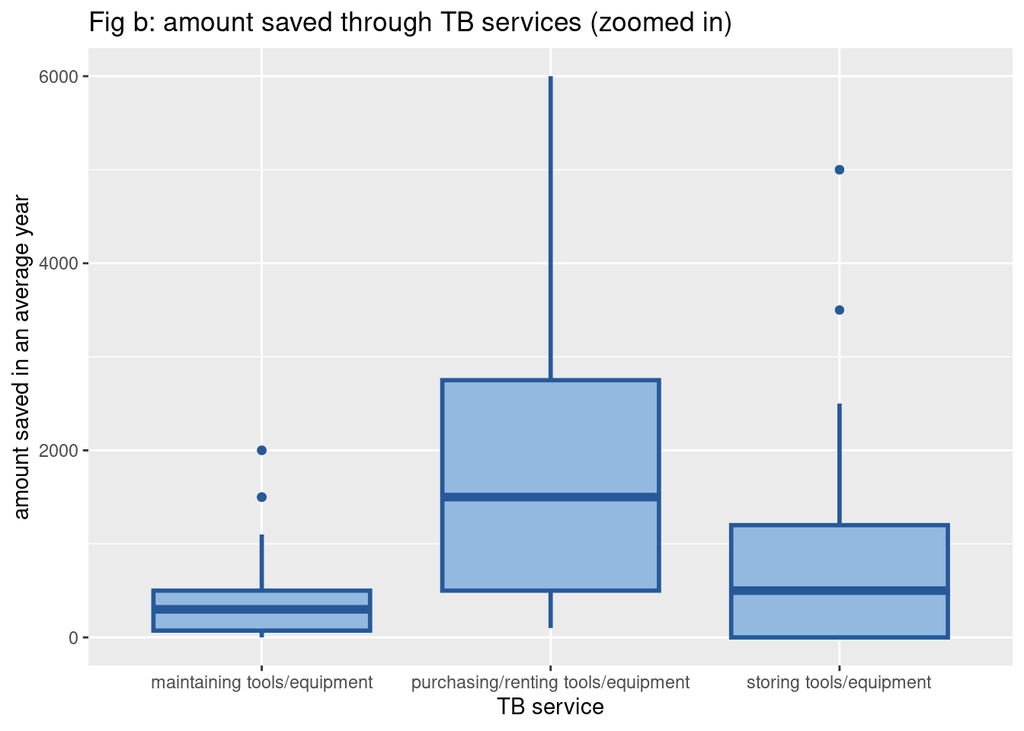

The following information addresses the question of which types of events have TB tools and equipment helped the CBO to complete

| Table 6: Ways community events would be impact without TB | Table 6: Ways community events would be impact without TB # Respondents | Table 6: Ways community events would be impact without TB % Respondents |
| --- | --- | --- |
| Choice* |  |  |
| Quantity | 25 | 55.6% |
| Quality | 35 | 77.8% |
| Diversity | 8 | 17.8% |
| Consistency | 30 | 66.7% |
| Other | 2 | 4.4% |

**Figure 25: Percentage for Ways Events Got Impacted without TB**

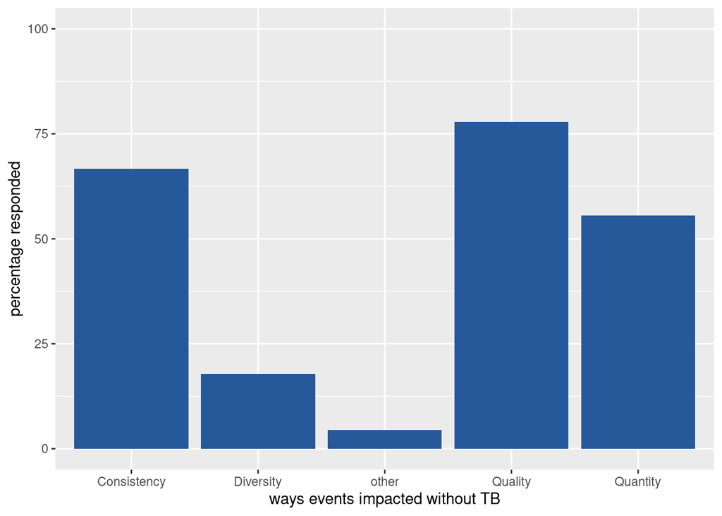

| Table 7: Events types TB helped to complete | Table 7: Events types TB helped to complete # Respondents | Table 7: Events types TB helped to complete % Respondents |
| --- | --- | --- |
| Choice* |  |  |
| Fundraising | 14 | 31.1% |
| Service Projects | 34 | 75.6% |
| Educational Workshops | 15 | 33.3% |
| Community Building | 38 | 84.4% |
| Other | 6 | 13.3% |

**Figure 27: Percentage for Event Types TB helps to Complete**

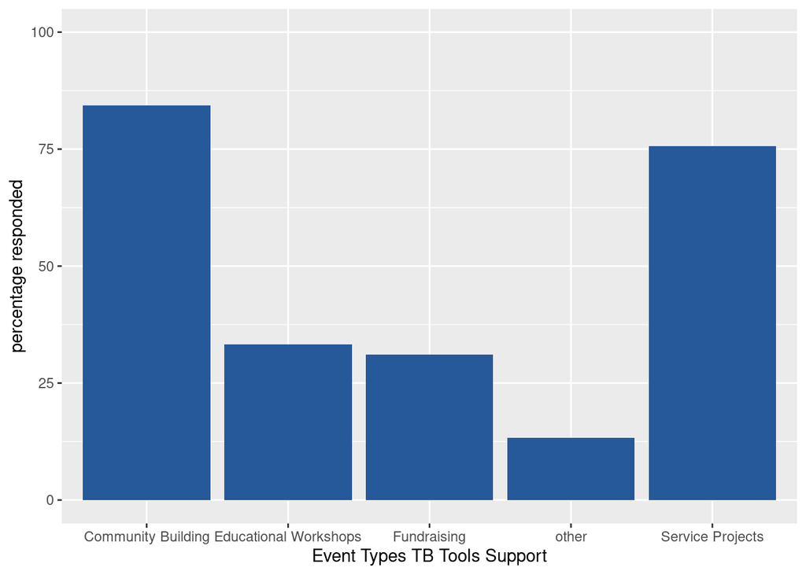

**Findings:**

- Respondents with more positive attitudes with the ToolBank helping reduce their costs in multiple aspects would have spent more on buying, storing and maintaining tools or equipment if the ToolBank did not exist (not statistically significant)
- The ToolBank helps to save the most in purchasing tools and equipment than storing and maintaining those (not statistically significant)
- Events got impacted by the TB mainly through their quality (77.8%), consistency (66.7%), and quantity (55.6%)
- The most prominent types of events the Toolbank supports are community building (84.4%) and service projects (75.6%)

The following information addresses the question of what percent of the event expense budget was saved by using TB equipment.

| Table 8: Event expense budget saved by using TB equipment | Table 8: Event expense budget saved by using TB equipment Mean | Table 8: Event expense budget saved by using TB equipment 25th quantile | Table 8: Event expense budget saved by using TB equipment Median | Table 8: Event expense budget saved by using TB equipment Mode | Table 8: Event expense budget saved by using TB equipment 75th quantile | Table 8: Event expense budget saved by using TB equipment Standard deviation |
| --- | --- | --- | --- | --- | --- | --- |
| % of event expense budget | 32.8 | 10 | 30 | 50 | 50 | 28.8 |

**Findings:**

- Half of the respondents reported that using the ToolBank helped their CBO save at least 30% of their event expense budget.